# Medical Insurance Dataset Modeling

### Importing all Libraries

```python
%matplotlib inline
import pandas as pd
import  numpy as np
import matplotlib
import matplotlib.pyplot as plt
import seaborn as sns
```

### Importing Dataset

```python
df = pd.read_csv('insurance.csv')
```

```python
df.head()
```

|  | age | sex | bmi | children | smoker | region | charges |
| --- | --- | --- | --- | --- | --- | --- | --- |
| 0 | 19 | female | 27.900 | 0 | yes | southwest | 16884.92400 |
| 1 | 18 | male | 33.770 | 1 | no | southeast | 1725.55230 |
| 2 | 28 | male | 33.000 | 3 | no | southeast | 4449.46200 |
| 3 | 33 | male | 22.705 | 0 | no | northwest | 21984.47061 |
| 4 | 32 | male | 28.880 | 0 | no | northwest | 3866.85520 |

```python
From the above data we can see that our df has 7 columns which include 'age', 'sex', 'bmi', 'smoker', 'region'
```

```python
df.info()
```

```
<class 'pandas.core.frame.DataFrame'>
RangeIndex: 1338 entries, 0 to 1337
Data columns (total 7 columns):
 #   Column    Non-Null Count  Dtype
---  ------    --------------  -----
 0   age       1338 non-null   int64
 1   sex       1338 non-null   object
 2   bmi       1338 non-null   float64
 3   children  1338 non-null   int64
 4   smoker    1338 non-null   object
 5   region    1338 non-null   object
 6   charges   1338 non-null   float64
dtypes: float64(2), int64(2), object(3)
memory usage: 73.3+ KB
```

```python
df.describe()
```

|  | age | bmi | children | charges |
| --- | --- | --- | --- | --- |
| count | 1338.000000 | 1338.000000 | 1338.000000 | 1338.000000 |
| mean | 39.207025 | 30.663397 | 1.094918 | 13270.422265 |
| std | 14.049960 | 6.098187 | 1.205493 | 12110.011237 |
| min | 18.000000 | 15.960000 | 0.000000 | 1121.873900 |
| 25% | 27.000000 | 26.296250 | 0.000000 | 4740.287150 |
| 50% | 39.000000 | 30.400000 | 1.000000 | 9382.033000 |
| 75% | 51.000000 | 34.693750 | 2.000000 | 16639.912515 |
| max | 64.000000 | 53.130000 | 5.000000 | 63770.428010 |

```python
df.shape
```

```
(1338, 7)
```

```python
df.columns.isnull().sum()
```

```
0
```

```python
df.columns
```

```
Index(['age', 'sex', 'bmi', 'children', 'smoker', 'region', 'charges'], dtype='object')
```

```python
df.duplicated().sum()
df.drop_duplicates(inplace=True)
df.shape
```

### Visualizing using charts

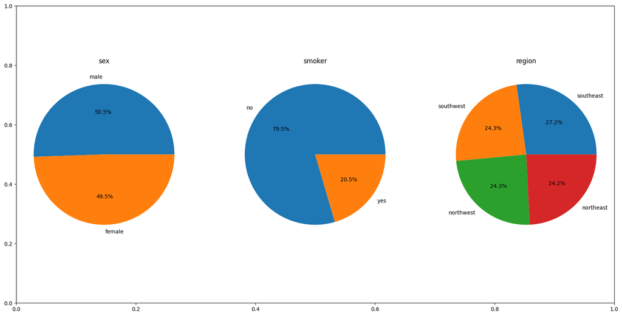

```python
### Pie chart for each catagorical features

features = ['sex', 'smoker', 'region']
plt.subplots(figsize=(20,10))

for i, col in enumerate(features):
    plt.subplot(1,3,i+1)

    x = df[col].value_counts()
    plt.pie(x.values, labels=x.index, autopct="%1.1f%%")
    plt.title(col)

plt.show()
```

### Observation

1. The ratio of male and female is almost same in the dataset.
2. People who smoke are paying more charges for their insurance.
3. There are 4 regions who's data is present.

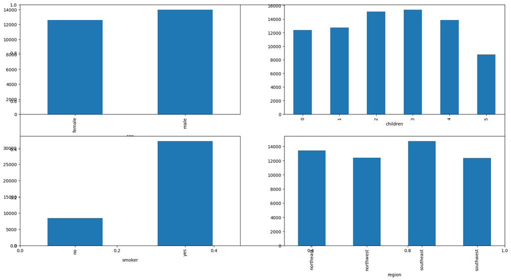

```python
### Making observation based on charges

features = ['sex', 'children', 'smoker', 'region']

plt.subplots(figsize=(20,10))

for i, col in enumerate(features):
    plt.subplot(2,2,i+1)
    df.groupby(col)['charges'].mean().astype(float).plot.bar()
plt.show()
```

### Observation

1. If the person has 1,2,3,4 childen then charges are accordingly.
2. If the person has 5 children, then charges are less compared to other.
3. The maximum charges are from SouthEast Region.
4. The charges for male is higher compared to charges for female.

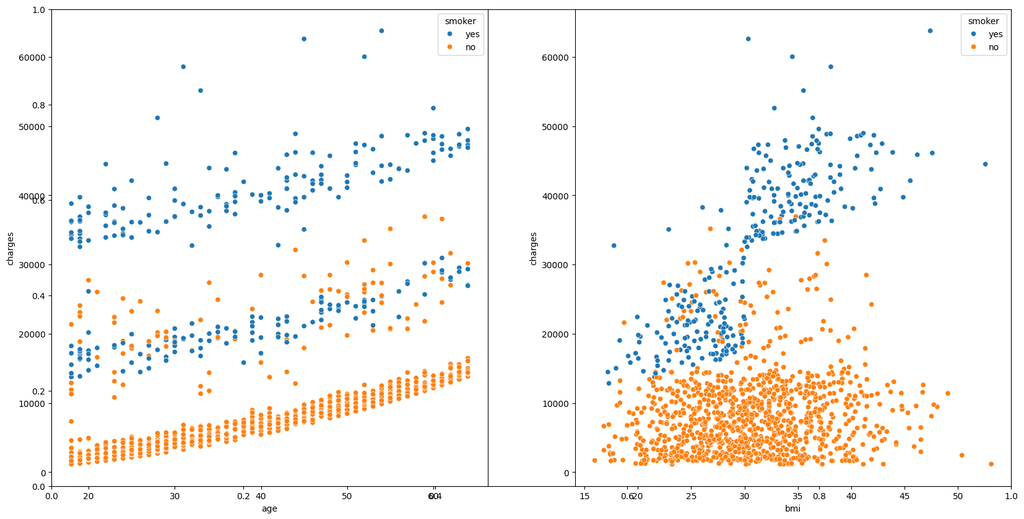

```python
features = ['age', 'bmi']

plt.subplots(figsize=(20,10))

for i, col in enumerate(features):
    plt.subplot(1,2,i+1)
    sns.scatterplot(data=df, x=col, y='charges', hue='smoker')
plt.show()
```

### Observations¶

1. People who are smoker are paying more charges compared to the people who does not smoke.
2. More the BMI, more the charges.
3. More the age, more the charges(slightly).

### Finding Outliers

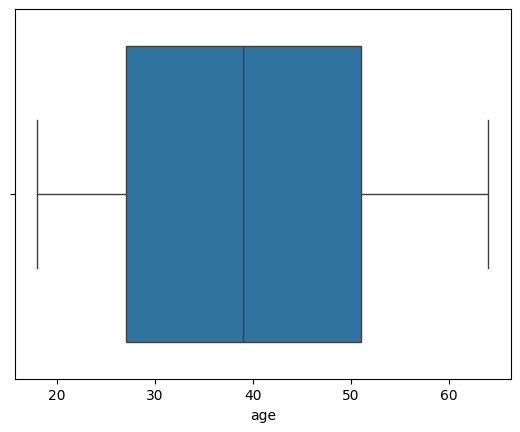

```python
### Checking if there is any outlier on data or not

sns.boxplot(x = df['age'])
plt.show()
```

Note: No outliers found in age column

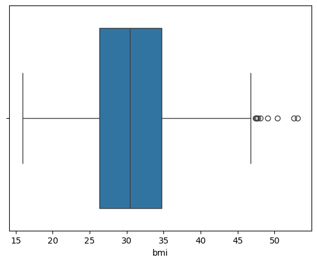

```python
sns.boxplot(x = df['bmi'])
plt.show()
```

Outlier found in BMI and it is above 45

### Removing Outliers

Its important to remove outliers for better model adapting the data.

```python
### Removing the outlier

arr = np.percentile(df['bmi'], [25, 75])

Q1 = arr[0]
Q3 = arr[1]
IQR = Q3 - Q1
lowerfence = Q1 - 1.5 * IQR
upperfence = Q3 + 1.5 * IQR
print(lowerfence)
print(upperfence)
```

```
13.674999999999994
47.31500000000001
```

```python
df = df[df['bmi'].between(13.674999999999994, 47.31500000000001)]
```

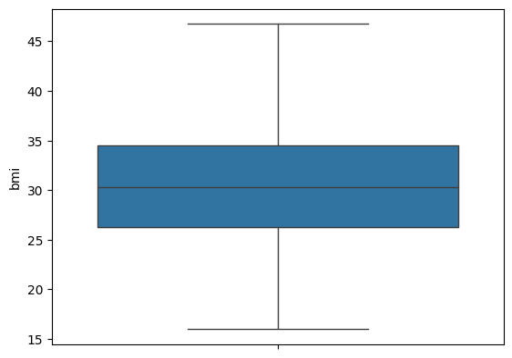

```python
sns.boxplot(df['bmi'])
plt.show()
```

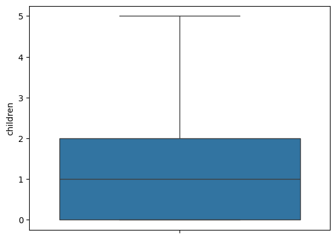

```python
sns.boxplot(df['children'])
plt.show()
```

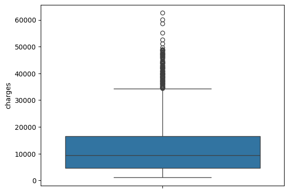

```python
sns.boxplot(df['charges'])
plt.show()
```

```python
df.shape
```

```
(1328, 7)
```

### Converting Catgorical Data to Numerical Data

```python
df['sex'] = df['sex'].map({'male':0, 'female':1})
df['smoker'] = df['smoker'].map({'yes':1, 'no':0})
df['region'] = df['region'].map({'southeast':1, 'northwest':2, 'southwest':3, 'northeast':4})
df.head()
```

|  | age | sex | bmi | children | smoker | region | charges |
| --- | --- | --- | --- | --- | --- | --- | --- |
| 0 | 19 | 1 | 27.900 | 0 | 1 | 3 | 16884.92400 |
| 1 | 18 | 0 | 33.770 | 1 | 0 | 1 | 1725.55230 |
| 2 | 28 | 0 | 33.000 | 3 | 0 | 1 | 4449.46200 |
| 3 | 33 | 0 | 22.705 | 0 | 0 | 2 | 21984.47061 |
| 4 | 32 | 0 | 28.880 | 0 | 0 | 2 | 3866.85520 |

```python
df.corr()
```

|  | age | sex | bmi | children | smoker | region | charges |
| --- | --- | --- | --- | --- | --- | --- | --- |
| age | 1.000000 | 0.018089 | 0.114785 | 0.042103 | -0.025075 | 0.009448 | 0.301317 |
| sex | 0.018089 | 1.000000 | -0.039966 | -0.019973 | -0.080269 | 0.003749 | -0.064161 |
| bmi | 0.114785 | -0.039966 | 1.000000 | 0.017366 | -0.002868 | -0.203921 | 0.193270 |
| children | 0.042103 | -0.019973 | 0.017366 | 1.000000 | 0.007234 | -0.004171 | 0.069125 |
| smoker | -0.025075 | -0.080269 | -0.002868 | 0.007234 | 1.000000 | -0.038247 | 0.785896 |
| region | 0.009448 | 0.003749 | -0.203921 | -0.004171 | -0.038247 | 1.000000 | -0.038515 |
| charges | 0.301317 | -0.064161 | 0.193270 | 0.069125 | 0.785896 | -0.038515 | 1.000000 |

### From the above correlation matrix, we can clearly see that

1. BMI 19%
2. Children 06%
3. Age 30%
4. Sex 06%
5. Smoker 78%
6. Region 03%

### Importing libraries and Model

```python
from sklearn.linear_model import LinearRegression
from sklearn.svm import SVR
from sklearn.ensemble import RandomForestRegressor
from sklearn.ensemble import GradientBoostingRegressor
import xgboost as xgb
from xgboost import XGBRegressor
from sklearn.model_selection import train_test_split
from sklearn.model_selection import cross_val_score
from sklearn.metrics import r2_score
```

```python
X = df.drop(['charges'], axis=1)
Y = df[['charges']]
```

```python
X
```

|  | age | sex | bmi | children | smoker | region |
| --- | --- | --- | --- | --- | --- | --- |
| 0 | 19 | 1 | 27.900 | 0 | 1 | 3 |
| 1 | 18 | 0 | 33.770 | 1 | 0 | 1 |
| 2 | 28 | 0 | 33.000 | 3 | 0 | 1 |
| 3 | 33 | 0 | 22.705 | 0 | 0 | 2 |
| 4 | 32 | 0 | 28.880 | 0 | 0 | 2 |
| ... | ... | ... | ... | ... | ... | ... |
| 1333 | 50 | 0 | 30.970 | 3 | 0 | 2 |
| 1334 | 18 | 1 | 31.920 | 0 | 0 | 4 |
| 1335 | 18 | 1 | 36.850 | 0 | 0 | 1 |
| 1336 | 21 | 1 | 25.800 | 0 | 0 | 3 |
| 1337 | 61 | 1 | 29.070 | 0 | 1 | 2 |

1328 rows × 6 columns

```python
Y
```

|  | charges |
| --- | --- |
| 0 | 16884.92400 |
| 1 | 1725.55230 |
| 2 | 4449.46200 |
| 3 | 21984.47061 |
| 4 | 3866.85520 |
| ... | ... |
| 1333 | 10600.54830 |
| 1334 | 2205.98080 |
| 1335 | 1629.83350 |
| 1336 | 2007.94500 |
| 1337 | 29141.36030 |

1328 rows × 1 columns

### Linear Regression Model

```python
### Working with linear Regression model
l1 = []
l2 = []
l3 = []
cvs = 0
for i in range(40,50):
    X_train, X_test, Y_train, Y_test = train_test_split(X, Y, test_size=0.2, random_state=i)
    lrmodel = LinearRegression()
    lrmodel.fit(X_train, Y_train)
    l1.append(lrmodel.score(X_train, Y_train))
    l2.append(lrmodel.score(X_test, Y_test))
    cvs = (cross_val_score(lrmodel, X, Y, cv=5)).mean()
    l3.append(cvs)
    df1 = pd.DataFrame({'train_accuracy':l1, 'test_accuracy':l2, 'cvs':l3})
```

```python
X_train, X_test, Y_train, Y_test = train_test_split(X, Y, test_size=0.2, random_state=42)
lrmodel = LinearRegression()
lrmodel.fit(X_train, Y_train)
print("Accuracy on Training Data: ", + lrmodel.score(X_train, Y_train))
print("Accuracy on test data: ", lrmodel.score(X_test, Y_test))
print("Accuracy on Orignal Dataframe: " , cross_val_score(lrmodel, X, Y, cv=5).mean())
```

```
Accuracy on Training Data:  0.748891275682046
Accuracy on test data:  0.7494017798954917
Accuracy on Orignal Dataframe:  0.7458176641634991
```

### Observation of Linear Regression Model

1. Accuracy on Training Data: 0.748891275682046
2. Accuracy on test data: 0.7494017798954917
3. Accuracy on Orignal Dataframe: 0.7458176641634991

### SVR Model

```python
### Working on SVR model

svrmodel = SVR()
svrmodel.fit(X_train, Y_train)
ypredtrain1 = svrmodel.predict(X_train)
ypredtest1 = svrmodel.predict(X_test)
```

```python
print(r2_score(Y_train, ypredtrain1))
print(r2_score(Y_test, ypredtest1))
print(cross_val_score(svrmodel, X, Y, cv=5).mean())
```

```
-0.09962249030636983
-0.09638377235140738
```

```
-0.10436712855501078
```

### Observation of SVR Model

1. Accuracy on Training Data: -0.09962249030636983
2. Accuracy on test data: -0.09638377235140738
3. Accuracy on Orignal Dataframe: -0.10436712855501078

**Seems like SVR model doesn't works well with the dataset.**

### Random Forest Regressor

```python
### Working on Random Forest Regressor

rfmodel = RandomForestRegressor(random_state = 42)
rfmodel.fit(X_train, Y_train)
ypredtrain2 = rfmodel.predict(X_train)
ypredtest2 = rfmodel.predict(X_test)
print(r2_score(Y_train, ypredtrain2))
print(r2_score(Y_test, ypredtest2))
print(cross_val_score(rfmodel, X, Y, cv=5).mean())
```

```
0.9771934743928201
0.8075733429888302
```

```
0.8284520616905396
```

### Observation of Random Forest Regressor Model

1. Accuracy on Training Data: 0.9771934743928201
2. Accuracy on test data: 0.8075733429888302
3. Accuracy on Orignal Dataframe: 0.8284520616905396

**Seems like Random Forest Regressor model gives better accuracy rate compared to other two.**

### XGboost Algorithm

1. Deal with null values
2. Identifies which feature is most important
3. Reduce overfitting

We are removing sex and region from the final training dataset. We cannot remove children because somehow it impacts the output.

```python
df.drop(df[['sex', 'region']], axis = 1, inplace=True)

Xfinal = df.drop(df[['charges']], axis=1)
X_train, X_test, Y_train, Y_test = train_test_split(Xfinal, Y, test_size=0.2, random_state=42)
```

```python
finalmodel = XGBRegressor(n_estimators=15, max_depth=3, gamma=0)
finalmodel.fit(X_train, Y_train)
ypredtrain4 = finalmodel.predict(X_train)
ypredtest4 = finalmodel.predict(X_test)
print(r2_score(Y_train, ypredtrain4))
print(r2_score(Y_test, ypredtest4))
print(cross_val_score(finalmodel, X, Y, cv=5).mean())
```

```
0.8804196119308472
0.8575218915939331
0.8604370594024658
```

## Comparing accuracy of all algorithm used

### Observation of Linear Regression Model

1. Accuracy on Training Data: 0.748891275682046
2. Accuracy on test data: 0.7494017798954917
3. Accuracy on Orignal Dataframe: 0.7458176641634991

### Observation of SVR Model

1. Accuracy on Training Data: -0.09962249030636983
2. Accuracy on test data: -0.09638377235140738
3. Accuracy on Orignal Dataframe: -0.10436712855501078

### Observation of Random Forest Regressor Model

1. Accuracy on Training Data: 0.9771934743928201
2. Accuracy on test data: 0.8075733429888302
3. Accuracy on Orignal Dataframe: 0.8284520616905396

### Observation of XGBoost Model

1. Accuracy on Training Data: 0.8804196119308472
2. Accuracy on test data: 0.8575218915939331
3. Accuracy on Orignal Dataframe: 0.8604370594024658

### Observations

1. RFR worked well with training dataset.
2. XGBoost works well with test data.

** Using XGboost to build final model.

```python
import pickle
pickle.dump(finalmodel, open("model.pkl", "wb"))
```